# Course Project

YC

2024-06-23

## Prepare Data and Packages

```r
library(tidyverse)
library(randomForest)
library(caret)
library(parallel)
library(doParallel)
library(rpart.plot)

url1 <- "https://d396qusza40orc.cloudfront.net/predmachlearn/pml-training.csv"
url2 <- "https://d396qusza40orc.cloudfront.net/predmachlearn/pml-testing.csv"
download.file(url1, destfile = "./data/training.csv")
download.file(url2, destfile = "./data/testing.csv")

training <- read_csv("./data/training.csv")
testing <- read_csv("./data/testing.csv")
```

## Exploratory Data Analysis

According to the research paper, there are 5 different fashions of performing Unilateral Dumbbell Biceps Curl:

- Class A: exactly according to the specification
- Class B: throwing the elbows to the front
- Class C: lifting the dumbbell only halfway
- Class D: lowering the dumbbell only halfway
- Class E: throwing the hips to the front

These are recorded in the `classe` variable in the given data set, which is the outcome variable in this course project.

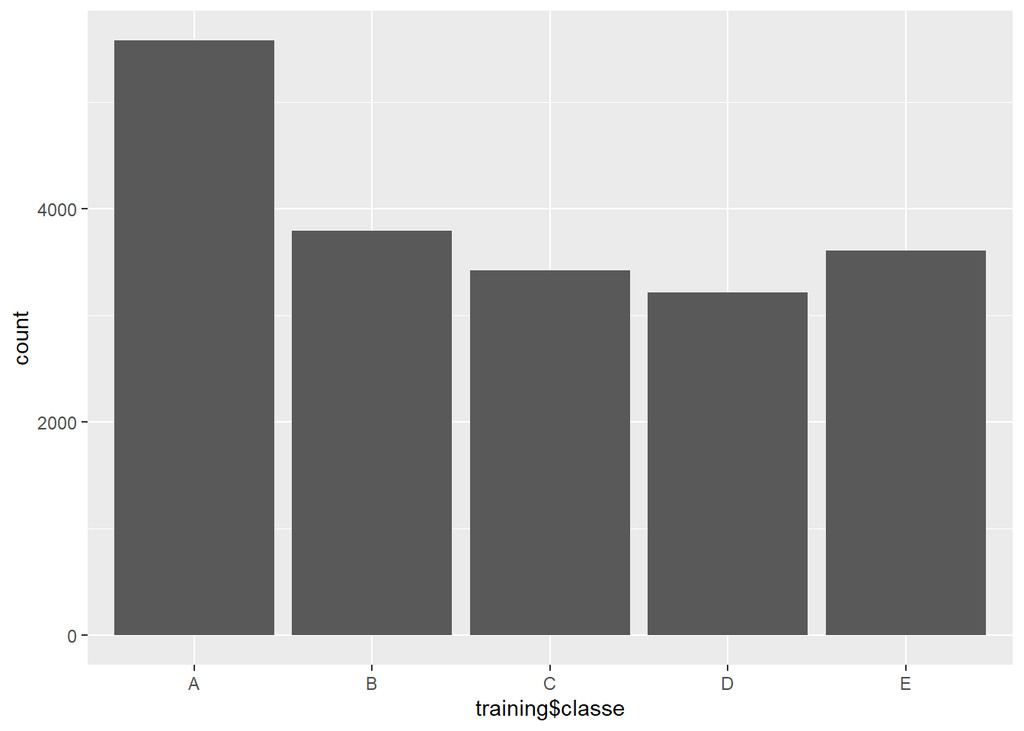

| A | B | C | D | E |
| --- | --- | --- | --- | --- |
| 5580 | 3797 | 3422 | 3216 | 3607 |

```r
ggplot(training, aes(x = training$classe)) +
    geom_bar()
```

Out of 19622 observations in the training set, 5580 of them (28%) are Class A, which corresponds to the specified execution of the exercise.

## Feature Selection & Data Processing

In this step, I will:

1. remove variables that have a large amount of missing values.
2. remove variables that are individual-specific: `...1`, `user_name`, `raw_timestamp_part_1`, `raw_timestamp_part_2`, `cvtd_timestamp`, `new_window`, and `num_window`.
3. remove near zero variance variables, which are not useful for prediction.
4. turn the output variable `classe` into a factor variable.

```r
na_percentage <- colSums(is.na(training)) / nrow(training)
training_r <- training %>%
    select(which(na_percentage<0.5)) %>% #(1)
    select(-c(1:7)) #(2)

nzv <- nearZeroVar(training_r)
training_r <- training_r %>%
    select(-nzv) #(3)

training_r$classe <- as.factor(training$classe) #(4)
```

## Create training set and testing set

```r
set.seed(24)
index_train <- createDataPartition(training_r$classe, p = 0.7, list = F)
train_data <- training_r[index_train,]
test_data <- training_r[-index_train,]
```

In this project, I employ two kinds of model. The first is *Decision Trees*, and then the more sophisticated *Random Forest*

## Decision Trees

#### Step 1: Configure Cross-validation & Fit the model

```r
set.seed(357)
fitControl_dt <- trainControl(method = "cv", number = 10)
dtModel <- train(classe ~ ., data = train_data, method = "rpart",
                 trControl = fitControl_dt,
                 tuneGrid = data.frame(cp = seq(0.01, 0.1, 0.01)))
```

I use a 10-fold cross validation here. Cross validation is used to estimate the out of sample error rate. By holding out a part of the training data for validation in each iteration, cross-validation provides a robust estimate of the model’s ability to generalize to new, unseen data. The average validation error across all folds provides a more stable and reliable estimate of the out-of-sample error rate than a single train-test split.

#### Step 2: Visualize the model

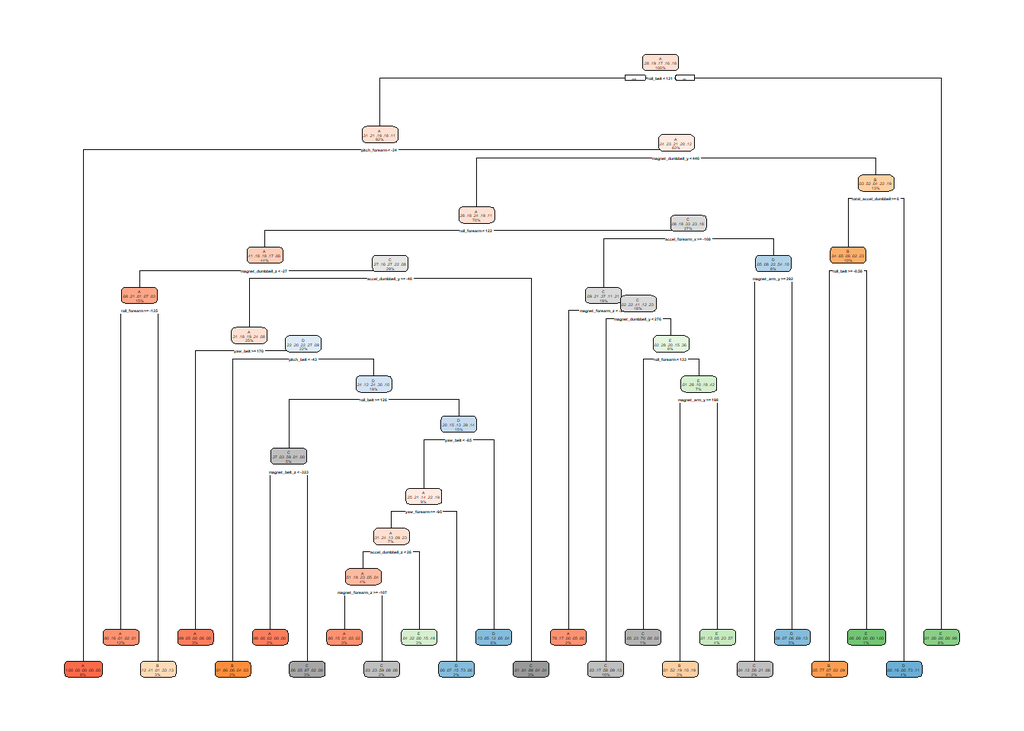

```r
rpart.plot(dtModel$finalModel)
```

#### Step 3 Predict on the test set

```r
set.seed(11)
prediction1 <- predict(dtModel, test_data)
confusionMatrix(prediction1, test_data$classe)
```

```
## Confusion Matrix and Statistics
##
##           Reference
## Prediction    A    B    C    D    E
##          A 1475  183   15   34   15
##          B   42  560   66   86   82
##          C   59  213  847   88  111
##          D   83   79   83  678   81
##          E   15  104   15   78  793
##
## Overall Statistics
##
##                Accuracy : 0.7397
##                  95% CI : (0.7283, 0.7509)
##     No Information Rate : 0.2845
##     P-Value [Acc > NIR] : < 2.2e-16
##
##                   Kappa : 0.6708
##
##  Mcnemar's Test P-Value : < 2.2e-16
##
## Statistics by Class:
##
##                      Class: A Class: B Class: C Class: D Class: E
## Sensitivity            0.8811  0.49166   0.8255   0.7033   0.7329
## Specificity            0.9413  0.94185   0.9031   0.9338   0.9559
## Pos Pred Value         0.8566  0.66986   0.6426   0.6753   0.7891
## Neg Pred Value         0.9522  0.88532   0.9608   0.9414   0.9408
## Prevalence             0.2845  0.19354   0.1743   0.1638   0.1839
## Detection Rate         0.2506  0.09516   0.1439   0.1152   0.1347
## Detection Prevalence   0.2926  0.14206   0.2240   0.1706   0.1708
## Balanced Accuracy      0.9112  0.71675   0.8643   0.8185   0.8444
```

The result accuracy is 74%, which corresponds to an out-of-sample error rate of 26%.

## Random Forest

#### Step 1: Configure Cross-validation and parallel processing

```r
set.seed(246)
cluster <- makeCluster(detectCores() - 1) # convention to leave 1 core for OS
registerDoParallel(cluster)
fitControl_rf <- trainControl(method = "cv", number = 10, allowParallel = TRUE)
```

Again, I use a 10-fold cross validation here. Cross validation is used to estimate the out of sample error rate. By holding out a part of the training data for validation in each iteration, cross-validation provides a robust estimate of the model’s ability to generalize to new, unseen data. The average validation error across all folds provides a more stable and reliable estimate of the out-of-sample error rate than a single train-test split.

In addition, to speed up processing time, I utilize parallel processing as instructed by course mentor Len Greski. See here: https://github.com/lgreski/datasciencectacontent/blob/master/markdown/pml-randomForestPerformance.md

#### Step 2: Develop a random forest model

```r
set.seed(22)
rfModel <- train(classe ~ ., data = train_data, method = "rf", trControl = fitControl_rf, ntree = 100)
stopCluster(cluster)
registerDoSEQ()
```

#### Step 3: Examine model summary and cross-validation results

```r
print(rfModel)
```

```
## Random Forest
##
## 13737 samples
##    52 predictor
##     5 classes: 'A', 'B', 'C', 'D', 'E'
##
## No pre-processing
## Resampling: Cross-Validated (10 fold)
## Summary of sample sizes: 12363, 12363, 12362, 12363, 12364, 12364, ...
## Resampling results across tuning parameters:
##
##   mtry  Accuracy   Kappa
##    2    0.9905361  0.9880270
##   27    0.9906097  0.9881209
##   52    0.9818742  0.9770707
##
## Accuracy was used to select the optimal model using the largest value.
## The final value used for the model was mtry = 27.
```

```r
print(rfModel$resample)
```

```
##     Accuracy     Kappa Resample
## 1  0.9883552 0.9852732   Fold02
## 2  0.9934498 0.9917154   Fold01
## 3  0.9861718 0.9825046   Fold04
## 4  0.9898182 0.9871225   Fold03
## 5  0.9912600 0.9889435   Fold06
## 6  0.9963583 0.9953940   Fold05
## 7  0.9832484 0.9788012   Fold08
## 8  0.9905455 0.9880382   Fold07
## 9  0.9934450 0.9917076   Fold10
## 10 0.9934450 0.9917085   Fold09
```

#### Step 4: Predict on the test set

```r
prediction2 <- predict(rfModel, test_data)
confusionMatrix(prediction2, test_data$classe)
```

```
## Confusion Matrix and Statistics
##
##           Reference
## Prediction    A    B    C    D    E
##          A 1672   12    0    0    0
##          B    1 1123    6    0    0
##          C    1    3 1017    7    2
##          D    0    1    3  957    4
##          E    0    0    0    0 1076
##
## Overall Statistics
##
##                Accuracy : 0.9932
##                  95% CI : (0.9908, 0.9951)
##     No Information Rate : 0.2845
##     P-Value [Acc > NIR] : < 2.2e-16
##
##                   Kappa : 0.9914
##
##  Mcnemar's Test P-Value : NA
##
## Statistics by Class:
##
##                      Class: A Class: B Class: C Class: D Class: E
## Sensitivity            0.9988   0.9860   0.9912   0.9927   0.9945
## Specificity            0.9972   0.9985   0.9973   0.9984   1.0000
## Pos Pred Value         0.9929   0.9938   0.9874   0.9917   1.0000
## Neg Pred Value         0.9995   0.9966   0.9981   0.9986   0.9988
## Prevalence             0.2845   0.1935   0.1743   0.1638   0.1839
## Detection Rate         0.2841   0.1908   0.1728   0.1626   0.1828
## Detection Prevalence   0.2862   0.1920   0.1750   0.1640   0.1828
## Balanced Accuracy      0.9980   0.9922   0.9943   0.9956   0.9972
```

## Predict on the original test set. (20 observations)

```r
predict(rfModel, newdata = testing)
```

```
##  [1] B A B A A E D B A A B C B A E E A B B B
## Levels: A B C D E
```

The accuracy is 100% in predicting the 20 unknown test cases.